# Predicting the Danceability of a Song Based on its Audio Features

## CMSC 320 Final Tutorial | Fall 2019 | John Dickerson Tuan Le, Joseph Johnson, Andrew Thai

[figure not shown]

*Image from* [newsroom.spotify](https://newsroom.spotify.com/2018-12-04/the-top-songs-artists-playlists-and-podcasts-of-2018/)

# Introduction

Music plays an important role in all of our lives and it has a profound cultural impact within society as a whole. Music has been created, shared, and cherished in every corner of the globe since the beginning of human civilization. It has grown and evolved with time, spawning many different genres and styles, each having its own unique elements.

Along with this, music has also birthed many of the world's most influential figures like Beethoven, The Beatles, Michael Jackson, Kanye West, and much more. Its power and influence in the world cannot be understated. Music brings happiness, excitment, energy, and love to everyone it touches.

When our group was brainstorming potential project ideas, we knew we wanted to choose a topic that we each deeply cared about. Also, we did not want a commonly used subject like sports or crime. We wanted a topic that not only plays a big role in our daily lives, but also impacts society for the better. In music, we found just that.

Our group decided to use [Kaggle](https://www.kaggle.com/datasets) to find potential datasets because it has a well organized list of ready-made, dataset repositories. We eventually discovered a dataset called [Top Spotify Tracks of 2018](https://www.kaggle.com/nadintamer/top-spotify-tracks-of-2018?fbclid=IwAR0zWvqeFYax4c39Sw8E9vLId6aESGx0SOotYqXUuanQCDwTwtCPFPSkiEM) by Nadin Tamer. We immediately realized that it had everything we wanted.

Spotify is one of the most popular music streaming platforms in the world today and everyone in our group uses it daily. At the end of each year, Spotify compiles a playlist of the songs streamed most often over the course of that year. This dataset includes the top 100 most streamed songs for 2018. Although there was a similar dataset for 2019, it only included the top 50 songs for 2019. As a result, we decided to work with the 2018 dataset because it has twice as much data. Additionally, there was also a similar dataset for 2017, but we felt that was too long ago.

As stated by Tamer, the audio features for each song were extracted using the Spotify Web API and the spotipy Python library. Credit goes to Spotify for calculating the audio feature values.

**Columns in this dataset:**

1. Spotify URI for the song
2. Name of the song
3. Artist(s) of the song
4. Danceability
5. Energy
6. Key
7. Loudness
8. Mode
9. Spechiness
10. Acousticness
11. Instrumentalness
12. Liveness
13. Valence
14. Tempo
15. Duration
16. Time Signature

There are 16 columns in total. Columns 1-3 describe the general details of a song while columns 4-16 describe the audio features a song.

Upon analyzing this dataset, we were very interested in the danceability element of a song. We were surprised and intrigued at how a song could be measured with this criteria. We wanted to find out how the other audio elements of a song can affect its danceability. As a result, this leads us to the goal of our tutorial, prediciting the danceability of a song based on the rest of its audio features.

# Audio Features Explained

**danceability**  
Danceability describes how suitable a track is for dancing based on a combination of musical elements including tempo, rhythm stability, beat strength, and overall regularity. A value of 0.0 is least danceable and 1.0 is most danceable.

**energy**  
Energy is a measure from 0.0 to 1.0 and represents a perceptual measure of intensity and activity. Typically, energetic tracks feel fast, loud, and noisy. For example, death metal has high energy, while a Bach prelude scores low on the scale. Perceptual features contributing to this attribute include dynamic range, perceived loudness, timbre, onset rate, and general entropy.

**key**  
The key the track is in. Integers map to pitches using standard Pitch Class notation. E.g. 0 = C, 1 = C♯/D♭, 2 = D, and so on.

**loudness**  
The overall loudness of a track in decibels (dB). Loudness values are averaged across the entire track and are useful for comparing relative loudness of tracks. Loudness is the quality of a sound that is the primary psychological correlate of physical strength (amplitude). Values typical range between -60 and 0 db.

**mode**  
Mode indicates the modality (major or minor) of a track, the type of scale from which its melodic content is derived. Major is represented by 1 and minor is 0.

**speechiness**  
Speechiness detects the presence of spoken words in a track. The more exclusively speech-like the recording (e.g. talk show, audio book, poetry), the closer to 1.0 the attribute value. Values above 0.66 describe tracks that are probably made entirely of spoken words. Values between 0.33 and 0.66 describe tracks that may contain both music and speech, either in sections or layered, including such cases as rap music. Values below 0.33 most likely represent music and other non-speech-like tracks.

**acousticness**  
A confidence measure from 0.0 to 1.0 of whether the track is acoustic. 1.0 represents high confidence the track is acoustic.

**instrumentalness**  
Predicts whether a track contains no vocals. "Ooh" and "aah" sounds are treated as instrumental in this context. Rap or spoken word tracks are clearly "vocal". The closer the instrumentalness value is to 1.0, the greater likelihood the track contains no vocal content. Values above 0.5 are intended to represent instrumental tracks, but confidence is higher as the value approaches 1.0.

**liveness**  
Detects the presence of an audience in the recording. Higher liveness values represent an increased probability that the track was performed live. A value above 0.8 provides strong likelihood that the track is live.

**valence**  
A measure from 0.0 to 1.0 describing the musical positiveness conveyed by a track. Tracks with high valence sound more positive (e.g. happy, cheerful, euphoric), while tracks with low valence sound more negative (e.g. sad, depressed, angry).

**tempo**  
The overall estimated tempo of a track in beats per minute (BPM). In musical terminology, tempo is the speed or pace of a given piece and derives directly from the average beat duration.

**duration_ms**  
The duration of the track in milliseconds.

**time_signature**  
An estimated overall time signature of a track. The time signature (meter) is a notational convention to specify how many beats are in each bar (or measure).

# Working with the Data - Data Curation, Parsing, and Management

In this tutorial, we will be working with Python 3. We make use of the following libraries: [pandas](https://pandas.pydata.org/pandas-docs/stable/), [numpy](https://docs.scipy.org/doc/numpy/user/), [mathplotlib](https://matplotlib.org/contents.html), [seaborn](https://seaborn.pydata.org/), [scikit-learn](https://scikit-learn.org/stable/index.html), and [statsmodels](https://www.statsmodels.org/stable/index.html). All code was written in Jupyter notebook.

```python
# The imports needed for this tutorial
import pandas as pd
import numpy as np
import matplotlib.pyplot as plt
import seaborn as sns
import warnings

from sklearn import model_selection
from sklearn import linear_model
from statsmodels import api

warnings.filterwarnings('ignore')
```

## Reading the Data

Upon downloading the .zip file from Kaggle, we unpackaged it to obtain the file top2018.csv. We used this file to access all the data used in this tutorial. To read in this data into Python, we used a Pandas dataframe and named it as data.

```python
data = pd.read_csv("top2018.csv")
data.head()
```

|  | id | name | artists | danceability | energy | key | loudness | mode | speechiness | acousticness | instrumentalness | liveness | valence | tempo | duration_ms | time_signature |
| --- | --- | --- | --- | --- | --- | --- | --- | --- | --- | --- | --- | --- | --- | --- | --- | --- |
| 0 | 6DCZcSspjsKoFjzjrWoCd | God's Plan | Drake | 0.754 | 0.449 | 7.0 | -9.211 | 1.0 | 0.1090 | 0.0332 | 0.000083 | 0.552 | 0.357 | 77.169 | 198973.0 | 4.0 |
| 1 | 3ee8Jmje8o58CHK66QrVC | SAD! | XXXTENTACION | 0.740 | 0.613 | 8.0 | -4.880 | 1.0 | 0.1450 | 0.2580 | 0.003720 | 0.123 | 0.473 | 75.023 | 166606.0 | 4.0 |
| 2 | 0e7ipj03S05BNilyu5bRz | rockstar (feat. 21 Savage) | Post Malone | 0.587 | 0.535 | 5.0 | -6.090 | 0.0 | 0.0898 | 0.1170 | 0.000066 | 0.131 | 0.140 | 159.847 | 218147.0 | 4.0 |
| 3 | 3swc6WTsr7rl9DqQKQA55 | Psycho (feat. Ty Dolla $ign) | Post Malone | 0.739 | 0.559 | 8.0 | -8.011 | 1.0 | 0.1170 | 0.5800 | 0.000000 | 0.112 | 0.439 | 140.124 | 221440.0 | 4.0 |
| 4 | 2G7V7zsVDxg1yRsu7Ew9R | In My Feelings | Drake | 0.835 | 0.626 | 1.0 | -5.833 | 1.0 | 0.1250 | 0.0589 | 0.000060 | 0.396 | 0.350 | 91.030 | 217925.0 | 4.0 |

## Tidying and Modifying the Data

Now that we have our dataset loaded, it is pretty clear that we can do some reorganization to make it more readable and efficient. The first thing that we are going to drop the "id" column because we do not have any use for it.

```python
data = data.drop(columns='id')
```

```python
data['duration_ms'] = data['duration_ms'].apply(lambda x: x / 60000)
```

Then, we are going to rename each of our columns to make them more readable and understandable.

```python
data.columns = ['Title', 'Artist', 'Danceability', 'Energy', 'Key', 'Loudness', 'Mode', 'Speechiness', 'Acousticness', 'Instrumentalness', 'Liveness', 'Valence', 'Tempo', 'Duration', 'Time_Signature']
```

Finally, we are going to rearrange the order of the columns to put our most important columns, the artist of the song, the title of the song, and the duration of the song, towards the left.

```python
data = data[['Artist', 'Title', 'Duration', 'Danceability', 'Energy', 'Key', 'Loudness', 'Mode', 'Speechiness', 'Acousticness', 'Instrumentalness', 'Liveness', 'Valence', 'Tempo', 'Time_Signature']]
```

Now, we can take a look at our transformed data set.

```python
data.head()
```

|  | Artist | Title | Duration | Danceability | Energy | Key | Loudness | Mode | Speechiness | Acousticness | Instrumentalness | Liveness | Valence | Tempo | Time_Signature |
| --- | --- | --- | --- | --- | --- | --- | --- | --- | --- | --- | --- | --- | --- | --- | --- |
| 0 | Drake | God's Plan | 3.316217 | 0.754 | 0.449 | 7.0 | -9.211 | 1.0 | 0.1090 | 0.0332 | 0.000083 | 0.552 | 0.357 | 77.169 | 4.0 |
| 1 | XXXTENTACION | SAD! | 2.776767 | 0.740 | 0.613 | 8.0 | -4.880 | 1.0 | 0.1450 | 0.2580 | 0.003720 | 0.123 | 0.473 | 75.023 | 4.0 |
| 2 | Post Malone | rockstar (feat. 21 Savage) | 3.635783 | 0.587 | 0.535 | 5.0 | -6.090 | 0.0 | 0.0898 | 0.1170 | 0.000066 | 0.131 | 0.140 | 159.847 | 4.0 |
| 3 | Post Malone | Psycho (feat. Ty Dolla $ign) | 3.690667 | 0.739 | 0.559 | 8.0 | -8.011 | 1.0 | 0.1170 | 0.5800 | 0.000000 | 0.112 | 0.439 | 140.124 | 4.0 |
| 4 | Drake | In My Feelings | 3.632083 | 0.835 | 0.626 | 1.0 | -5.833 | 1.0 | 0.1250 | 0.0589 | 0.000060 | 0.396 | 0.350 | 91.030 | 4.0 |

Wow, our dataframe now looks so much better than before!

# Exploratory Data Analysis

For this section, we will be taking an in-depth look at the data. We will be exploring areas such as most popular songs, artists with more than one song in the Top 100, most danceable songs, danceability vs popularitiy, and more. Through our data exploration and analysis, we are searching for any potential trends or patterns.

We will be graphically displaying this data through bar graphs, heatmaps, violin plots, and more. By using a variety of graphs, we hope to gain a better understanding of the different correlations between the audio deatures. Ultimately, we want to find out if there are any relationships between the audio features of a song and its danceability value.

## Most Popular Artists of the Year

To start off, let's take a look at how many artists there were in the Top 100 Songs of 2018.

```python
len(data['Artist'].unique())
```

```
70
```

There were 70 different artists in the Top 100 Songs of 2018, which means that there were some artists with more than one song. In order to see to how many songs each artist had in the Top 100, we can look through the Artist column of the dataframe and count how many songs each artist had.

```python
by_artist = data.groupby(data['Artist']).count().reset_index()
by_artist = by_artist[['Artist', 'Title']]
by_artist = by_artist.sort_values('Title', ascending=False)
by_artist.columns = ['Artist','Number of Songs']
by_artist.head(20)
```

|  | Artist | Number of Songs |
| --- | --- | --- |
| 52 | Post Malone | 6 |
| 65 | XXXTENTACION | 6 |
| 21 | Drake | 4 |
| 24 | Ed Sheeran | 3 |
| 42 | Marshmello | 3 |
| 22 | Dua Lipa | 2 |
| 28 | Imagine Dragons | 2 |
| 49 | Ozuna | 2 |
| 57 | Selena Gomez | 2 |
| 14 | Clean Bandit | 2 |
| 60 | The Weeknd | 2 |
| 41 | Maroon 5 | 2 |
| 11 | Calvin Harris | 2 |
| 32 | Kendrick Lamar | 2 |
| 33 | Khalid | 2 |
| 4 | Ariana Grande | 2 |
| 43 | Migos | 2 |
| 12 | Camila Cabello | 2 |
| 47 | Nio Garcia | 1 |
| 48 | Offset | 1 |

From our new dataframe, we can see that the artists with the most songs in Top 100 of 2018 were Post Malone and XXXTENTACION, who were both tied for first place with six songs each. In second place was Drake at four songs. Next, tied for third place was Ed Sheeran and Marshmello with three song each. Then, artists with two songs each include Dua Lipa, Imagine Dragons, Ozuna, Selena Gomez, Clean Bandit, The Weeknd, Maroon 5, Calvin Harris, Kendrick Lamar, Khalid, Ariana Grande, Migos, and Camila Cabello. Here is a plot of all 70 artists in the Top 100 Songs of 2018 in a bar chart to show how many songs they had in the Top 100.

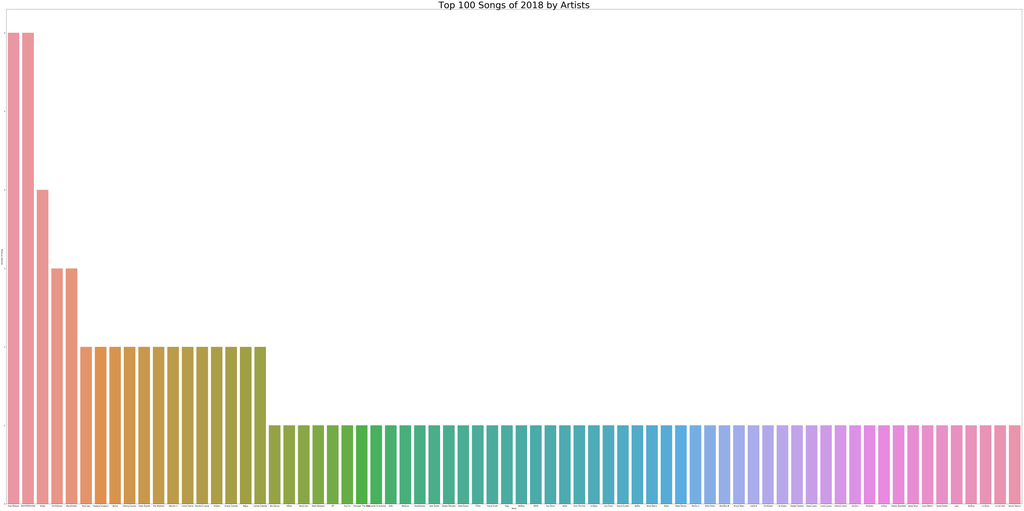

```python
plt.figure(figsize=(100,50))
sns.barplot(data=by_artist, x='Artist', y='Number of Songs')
plt.title("Top 100 Songs of 2018 by Artists", fontsize=50)
plt.show()
```

This graph gives us a good visual picture of how many artists have multiple songs in the Top 100. However, the graph is very streched out, so it is difficult distinguish between the artists. Below is the same bar graph with the artists that had more than one song in the Top 100 of 2018. However, we have reduced the size of the data to the top 18 artists for better viewability and simplicity.

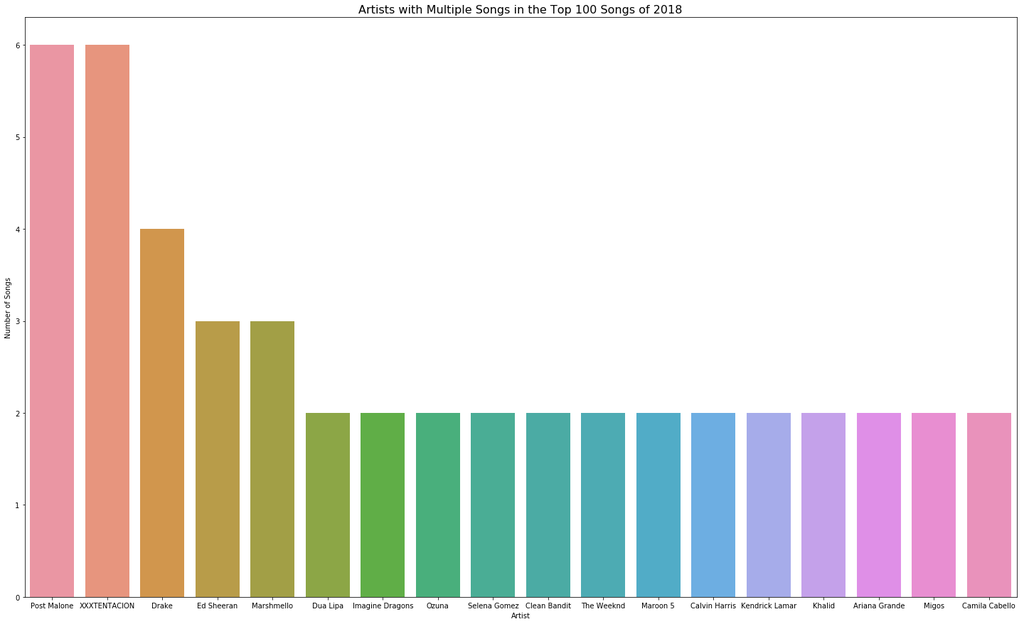

```python
repeats = by_artist[by_artist['Number of Songs'] > 1]
plt.figure(figsize=(25,15))
sns.barplot(data=repeats, x='Artist', y='Number of Songs')
plt.title("Artists with Multiple Songs in the Top 100 Songs of 2018", fontsize=16)
plt.show()
```

Now that we know which artist had the most songs in the Top 100 of 2018, we can see if they are more danceable than songs that aren't as popular. Here is a scatter plot on the danceability of songs and it is grouped by how many songs the artist had in the Top 100 Songs of 2018.

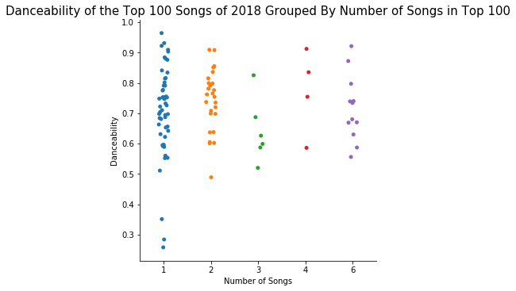

```python
concat = pd.merge(left=data, right=by_artist, how='left', left_on='Artist', right_on='Artist')
sns.catplot(x="Number of Songs", y="Danceability",  data=concat)
plt.title("Danceability of the Top 100 Songs of 2018 Grouped By Number of Songs in Top 100", fontsize=15)
plt.show()
```

As you can see, it does not look like danceability is a trend among the popularity of a song. For the songs made by artists with the most songs in the Top 100, the songs do vary in danceability by a lot and their values are no higher than the songs that are produced by artists with less songs in the Top 100.

Here is the same data in a violin plot of the danceability of the top songs of 2018.

```
Text(0.5,1,'Danceability of the Top 100 Songs of 2018 Grouped By Number of Songs in Top 100')
```

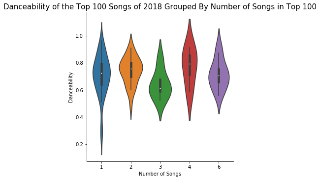

```python
sns.catplot(x="Number of Songs", y="Danceability", kind="violin", data=concat)
plt.title("Danceability of the Top 100 Songs of 2018 Grouped By Number of Songs in Top 100", fontsize=15)
```

## Exploring The Most Danceable Songs and Artists

Now that we have seen the most popular artists in the Top 100, we will now take a long at the most danceable songs and artists of 2018. As a reminder, this dataset uses this metric to describe how suitable a track is for dancing based on a combination of musical elements including tempo, rhythm stability, beat strength, and overall regularity. A value of 0.0 is least danceable and 1.0 is most danceable.

```python
dance = data.copy().sort_values('Danceability', ascending=False)
dance.head()
```

|  | Artist | Title | Duration | Danceability | Energy | Key | Loudness | Mode | Speechiness | Acousticness | Instrumentalness | Liveness | Valence | Tempo | Time_Signature |
| --- | --- | --- | --- | --- | --- | --- | --- | --- | --- | --- | --- | --- | --- | --- | --- |
| 91 | Lil Baby | Yes Indeed | 2.371217 | 0.964 | 0.346 | 5.0 | -9.309 | 0.0 | 0.5300 | 0.03500 | 0.000000 | 0.108 | 0.562 | 119.958 | 4.0 |
| 55 | 6ix9ine | FEFE (feat. Nicki Minaj & Murda Beatz) | 2.990083 | 0.931 | 0.387 | 1.0 | -9.127 | 1.0 | 0.4120 | 0.08800 | 0.000000 | 0.136 | 0.376 | 125.978 | 4.0 |
| 19 | BlocBoy JB | Look Alive (feat. Drake) | 3.021050 | 0.922 | 0.581 | 10.0 | -7.495 | 1.0 | 0.2700 | 0.00104 | 0.000059 | 0.105 | 0.595 | 140.022 | 4.0 |
| 18 | XXXTENTACION | Moonlight | 2.251500 | 0.921 | 0.537 | 9.0 | -5.723 | 0.0 | 0.0804 | 0.55600 | 0.004040 | 0.102 | 0.711 | 128.009 | 4.0 |
| 61 | Drake | Nonstop | 3.976900 | 0.912 | 0.412 | 7.0 | -8.074 | 1.0 | 0.1240 | 0.01640 | 0.013000 | 0.104 | 0.422 | 154.983 | 4.0 |

Much to our surprise, the most danceable song of 2018 was "Yes Indeed" by Lil Baby. This is unfortunate because in our opinion, there are many songs that are better suited to dance to. Anyways, it appears that the most danceable songs of the year do not look to be the most popular songs of the year. Let's see what happens when we plot the danceability of all of the songs of the year in the order of their popularity.

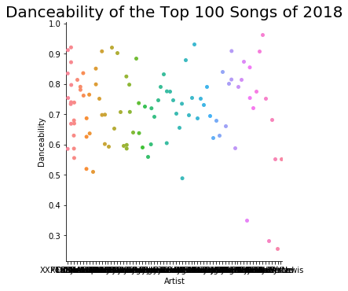

```python
plt.figure(figsize=(500,100))
sns.catplot(x="Artist", y="Danceability", data=data)
plt.title("Danceability of the Top 100 Songs of 2018", fontsize=20)
plt.show()
```

As seen in the plot above, it does not look like the most popular songs of the year are seen as very danceable.

Now, we will take a look at if certain artists are more danceable than others. First, we will find the average for all values for each artist in the Top 100 Songs of 2018.

```python
avg_data = data.groupby("Artist").mean()
avg_data.head()
```

| Artist | Duration | Danceability | Energy | Key | Loudness | Mode | Speechiness | Acousticness | Instrumentalness | Liveness | Valence | Tempo | Time_Signature |
| --- | --- | --- | --- | --- | --- | --- | --- | --- | --- | --- | --- | --- | --- |
| 5 Seconds of Summer | 3.390300 | 0.5960 | 0.8540 | 7.0 | -5.1140 | 0.0 | 0.4630 | 0.01690 | 0.000000 | 0.1240 | 0.152 | 120.274 | 4.0 |
| 6ix9ine | 2.990083 | 0.9310 | 0.3870 | 1.0 | -9.1270 | 1.0 | 0.4120 | 0.08800 | 0.000000 | 0.1360 | 0.376 | 125.978 | 4.0 |
| Anitta | 3.224267 | 0.7750 | 0.6790 | 4.0 | -4.9850 | 0.0 | 0.1350 | 0.18000 | 0.000073 | 0.0680 | 0.619 | 166.008 | 4.0 |
| Anne-Marie | 3.116450 | 0.6970 | 0.6830 | 1.0 | -2.8810 | 0.0 | 0.1170 | 0.03720 | 0.000000 | 0.1370 | 0.603 | 96.133 | 4.0 |
| Ariana Grande | 3.362225 | 0.6505 | 0.6855 | 5.0 | -5.7205 | 0.5 | 0.0576 | 0.03165 | 0.000032 | 0.2655 | 0.311 | 133.512 | 4.0 |

Now that we have a dataframe with the average values for each of the artists, we will now take a look at which artist is the most danceable on average.

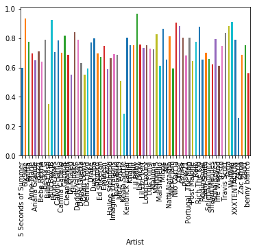

```python
data.groupby('Artist')['Danceability'].mean().plot(kind="bar")
plt.show()
```

After plotting the average danceability for each artist, it can be seen that some artists are more danceable than others. However, this may be a little difficult to read due to the amount of artists being plotted, so let's take a simplified look at this instead.

```python
avg_data.sort_values("Danceability", ascending=False)
```

| Artist | Duration | Danceability | Energy | Key | Loudness | Mode | Speechiness | Acousticness | Instrumentalness | Liveness | Valence | Tempo | Time_Signature |
| --- | --- | --- | --- | --- | --- | --- | --- | --- | --- | --- | --- | --- | --- |
| Lil Baby | 2.371217 | 0.964000 | 0.346000 | 5.000000 | -9.309000 | 0.000000 | 0.530000 | 0.035000 | 0.000000e+00 | 0.108000 | 0.562000 | 119.958000 | 4.000000 |
| 6ix9ine | 2.990083 | 0.931000 | 0.387000 | 1.000000 | -9.127000 | 1.000000 | 0.412000 | 0.088000 | 0.000000e+00 | 0.136000 | 0.376000 | 125.978000 | 4.000000 |
| BlocBoy JB | 3.021050 | 0.922000 | 0.581000 | 10.000000 | -7.495000 | 1.000000 | 0.270000 | 0.001040 | 5.860000e-05 | 0.105000 | 0.595000 | 140.022000 | 4.000000 |
| Wolfine | 3.285333 | 0.909000 | 0.493000 | 3.000000 | -6.688000 | 1.000000 | 0.073500 | 0.128000 | 1.470000e-04 | 0.127000 | 0.844000 | 94.016000 | 4.000000 |
| Nio Garcia | 6.965333 | 0.903000 | 0.675000 | 11.000000 | -3.445000 | 0.000000 | 0.214000 | 0.542000 | 1.280000e-05 | 0.059500 | 0.442000 | 96.507000 | 4.000000 |
| Tyga | 3.882650 | 0.884000 | 0.559000 | 0.000000 | -7.442000 | 1.000000 | 0.120000 | 0.023600 | 0.000000e+00 | 0.101000 | 0.342000 | 97.994000 | 4.000000 |
| Offset | 2.880000 | 0.880000 | 0.428000 | 9.000000 | -8.280000 | 1.000000 | 0.206000 | 0.149000 | 5.070000e-05 | 0.114000 | 0.333000 | 100.007000 | 4.000000 |
| Rich The Kid | 2.920500 | 0.876000 | 0.519000 | 11.000000 | -6.531000 | 1.000000 | 0.143000 | 0.202000 | 0.000000e+00 | 0.108000 | 0.158000 | 94.981000 | 4.000000 |
| Migos | 3.886958 | 0.862000 | 0.722000 | 2.000000 | -5.465000 | 1.000000 | 0.235000 | 0.038445 | 0.000000e+00 | 0.133500 | 0.452000 | 163.936000 | 4.000000 |
| DJ Snake | 3.541667 | 0.841000 | 0.798000 | 1.000000 | -4.206000 | 0.000000 | 0.229000 | 0.153000 | 3.330000e-06 | 0.061800 | 0.591000 | 95.948000 | 4.000000 |
| Travis Scott | 5.213667 | 0.834000 | 0.730000 | 8.000000 | -3.714000 | 1.000000 | 0.222000 | 0.005130 | 0.000000e+00 | 0.124000 | 0.446000 | 155.008000 | 4.000000 |
| Maroon 5 | 3.628283 | 0.825000 | 0.569000 | 2.500000 | -5.978000 | 0.500000 | 0.055800 | 0.323400 | 2.830000e-06 | 0.115000 | 0.433500 | 117.480000 | 4.000000 |
| Cardi B | 4.223167 | 0.816000 | 0.726000 | 5.000000 | -3.998000 | 0.000000 | 0.129000 | 0.099000 | 0.000000e+00 | 0.372000 | 0.650000 | 136.048000 | 4.000000 |
| Natti Natasha | 3.875833 | 0.814000 | 0.813000 | 2.000000 | -3.023000 | 0.000000 | 0.056100 | 0.030000 | 9.330000e-05 | 0.255000 | 0.839000 | 79.997000 | 4.000000 |
| Ozuna | 3.357775 | 0.804500 | 0.734500 | 7.500000 | -5.679500 | 0.500000 | 0.067950 | 0.240000 | 1.985000e-05 | 0.148350 | 0.590500 | 95.999000 | 4.000000 |
| Kendrick Lamar | 3.409892 | 0.803000 | 0.627000 | 4.500000 | -5.792000 | 0.500000 | 0.080850 | 0.030391 | 1.239500e-04 | 0.094200 | 0.486500 | 123.467500 | 4.000000 |
| Portugal. The Man | 2.720883 | 0.801000 | 0.795000 | 1.000000 | -5.115000 | 0.000000 | 0.050400 | 0.041700 | 1.130000e-04 | 0.071700 | 0.754000 | 79.028000 | 4.000000 |
| Dua Lipa | 3.560558 | 0.799000 | 0.622000 | 8.000000 | -5.998000 | 0.500000 | 0.081850 | 0.021455 | 7.800000e-06 | 0.117700 | 0.559000 | 106.550500 | 4.000000 |
| Sofia Reyes | 3.358767 | 0.792000 | 0.895000 | 1.000000 | -3.112000 | 0.000000 | 0.058900 | 0.165000 | 0.000000e+00 | 0.050100 | 0.794000 | 94.968000 | 4.000000 |
| Daddy Yankee | 3.341333 | 0.791000 | 0.848000 | 1.000000 | -3.456000 | 1.000000 | 0.050600 | 0.183000 | 0.000000e+00 | 0.409000 | 0.828000 | 95.000000 | 4.000000 |
| Becky G | 3.142667 | 0.791000 | 0.745000 | 11.000000 | -3.695000 | 0.000000 | 0.046400 | 0.354000 | 2.930000e-05 | 0.104000 | 0.820000 | 94.014000 | 4.000000 |
| XXXTENTACION | 2.179731 | 0.788833 | 0.492000 | 5.833333 | -7.770167 | 0.333333 | 0.111767 | 0.505033 | 1.322922e-03 | 0.139233 | 0.526500 | 110.496000 | 4.000000 |
| Calvin Harris | 3.567967 | 0.786000 | 0.815000 | 10.000000 | -4.615500 | 0.500000 | 0.074700 | 0.024450 | 1.340500e-05 | 0.203200 | 0.539000 | 123.532000 | 4.000000 |
| Reik | 3.694217 | 0.777000 | 0.779000 | 0.000000 | -4.449000 | 0.000000 | 0.097200 | 0.054300 | 0.000000e+00 | 0.636000 | 0.768000 | 94.023000 | 4.000000 |
| Anitta | 3.224267 | 0.775000 | 0.679000 | 4.000000 | -4.985000 | 0.000000 | 0.135000 | 0.180000 | 7.260000e-05 | 0.068000 | 0.619000 | 166.008000 | 4.000000 |
| Drake | 3.609412 | 0.771750 | 0.599000 | 5.750000 | -7.398000 | 1.000000 | 0.107125 | 0.049400 | 3.312975e-03 | 0.292750 | 0.471500 | 104.144000 | 4.000000 |
| Lil Dicky | 3.610533 | 0.755000 | 0.599000 | 8.000000 | -5.042000 | 1.000000 | 0.224000 | 0.147000 | 0.000000e+00 | 0.109000 | 0.755000 | 133.123000 | 4.000000 |
| Zedd | 3.078867 | 0.753000 | 0.657000 | 7.000000 | -3.061000 | 1.000000 | 0.044900 | 0.171000 | 0.000000e+00 | 0.112000 | 0.437000 | 107.010000 | 4.000000 |
| Khalid | 3.368783 | 0.753000 | 0.593500 | 3.500000 | -5.988500 | 1.000000 | 0.043500 | 0.147300 | 8.300000e-06 | 0.149500 | 0.366000 | 140.452000 | 4.000000 |
| Lauv | 3.290617 | 0.752000 | 0.505000 | 9.000000 | -7.621000 | 1.000000 | 0.253000 | 0.535000 | 2.550000e-06 | 0.104000 | 0.419000 | 91.970000 | 4.000000 |
| ... | ... | ... | ... | ... | ... | ... | ... | ... | ... | ... | ... | ... | ... |
| Anne-Marie | 3.116450 | 0.697000 | 0.683000 | 1.000000 | -2.881000 | 0.000000 | 0.117000 | 0.037200 | 0.000000e+00 | 0.137000 | 0.603000 | 96.133000 | 4.000000 |
| Dynoro | 3.076000 | 0.694000 | 0.770000 | 6.000000 | -5.335000 | 1.000000 | 0.149000 | 0.176000 | 1.100000e-05 | 0.118000 | 0.163000 | 125.905000 | 4.000000 |
| Imagine Dragons | 3.262450 | 0.690500 | 0.801000 | 5.000000 | -4.603500 | 0.500000 | 0.085900 | 0.034455 | 6.700000e-02 | 0.114000 | 0.477000 | 146.473000 | 4.000000 |
| Clean Bandit | 3.570008 | 0.687500 | 0.647000 | 7.000000 | -5.432000 | 0.500000 | 0.044650 | 0.144550 | 3.518500e-05 | 0.220950 | 0.447500 | 105.040500 | 4.000000 |
| Jonas Blue | 3.240133 | 0.687000 | 0.785000 | 1.000000 | -4.650000 | 1.000000 | 0.033300 | 0.327000 | 0.000000e+00 | 0.203000 | 0.655000 | 106.046000 | 4.000000 |
| Zac Efron | 3.624000 | 0.684000 | 0.619000 | 10.000000 | -7.005000 | 1.000000 | 0.038600 | 0.071600 | 0.000000e+00 | 0.122000 | 0.284000 | 125.046000 | 4.000000 |
| Piso 21 | 3.668617 | 0.681000 | 0.788000 | 1.000000 | -4.323000 | 1.000000 | 0.078500 | 0.048200 | 0.000000e+00 | 0.075300 | 0.839000 | 170.019000 | 4.000000 |
| Ed Sheeran | 4.203683 | 0.670333 | 0.466333 | 5.666667 | -5.620000 | 0.666667 | 0.043233 | 0.507667 | 0.000000e+00 | 0.107367 | 0.485000 | 95.339667 | 3.333333 |
| Hailee Steinfeld | 2.913333 | 0.663000 | 0.708000 | 8.000000 | -4.154000 | 1.000000 | 0.047300 | 0.033700 | 0.000000e+00 | 0.084100 | 0.742000 | 103.073000 | 4.000000 |
| Selena Gomez | 3.382483 | 0.660500 | 0.765500 | 8.500000 | -4.723000 | 0.500000 | 0.045900 | 0.111750 | 8.400000e-07 | 0.151500 | 0.406500 | 113.503500 | 4.000000 |
| NF | 3.535333 | 0.656000 | 0.721000 | 5.000000 | -5.665000 | 0.000000 | 0.122000 | 0.298000 | 0.000000e+00 | 0.173000 | 0.468000 | 148.066000 | 4.000000 |
| Rudimental | 3.512883 | 0.653000 | 0.809000 | 0.000000 | -4.057000 | 1.000000 | 0.047400 | 0.194000 | 0.000000e+00 | 0.165000 | 0.550000 | 92.213000 | 4.000000 |
| Ariana Grande | 3.362225 | 0.650500 | 0.685500 | 5.000000 | -5.720500 | 0.500000 | 0.057600 | 0.031650 | 3.155500e-05 | 0.265500 | 0.311000 | 133.512000 | 4.000000 |
| Post Malone | 3.727853 | 0.643667 | 0.608833 | 6.833333 | -5.913167 | 0.666667 | 0.079950 | 0.326983 | 1.110333e-05 | 0.149833 | 0.362333 | 148.686500 | 4.000000 |
| Bebe Rexha | 2.736750 | 0.642000 | 0.772000 | 10.000000 | -6.610000 | 1.000000 | 0.084800 | 0.047600 | 0.000000e+00 | 0.064600 | 0.589000 | 153.995000 | 4.000000 |
| David Guetta | 3.244667 | 0.631000 | 0.649000 | 5.000000 | -5.892000 | 0.000000 | 0.038500 | 0.081700 | 3.800000e-06 | 0.093400 | 0.421000 | 93.950000 | 4.000000 |
| Shawn Mendes | 3.522667 | 0.622000 | 0.712000 | 5.000000 | -7.321000 | 1.000000 | 0.066000 | 0.057300 | 0.000000e+00 | 0.130000 | 0.487000 | 140.025000 | 4.000000 |
| The Weeknd | 3.665108 | 0.612000 | 0.637500 | 1.500000 | -4.954000 | 1.000000 | 0.064500 | 0.147100 | 1.085000e-05 | 0.230500 | 0.180000 | 117.314500 | 3.500000 |
| Marshmello | 3.320744 | 0.611000 | 0.811000 | 6.000000 | -2.742000 | 0.666667 | 0.060300 | 0.217333 | 1.653333e-06 | 0.155000 | 0.497000 | 112.355000 | 4.000000 |
| 5 Seconds of Summer | 3.390300 | 0.596000 | 0.854000 | 7.000000 | -5.114000 | 0.000000 | 0.463000 | 0.016900 | 0.000000e+00 | 0.124000 | 0.152000 | 120.274000 | 4.000000 |
| Nicky Jam | 2.893800 | 0.595000 | 0.773000 | 9.000000 | -4.736000 | 0.000000 | 0.054900 | 0.036400 | 1.080000e-03 | 0.334000 | 0.711000 | 180.073000 | 4.000000 |
| Dennis Lloyd | 2.610000 | 0.592000 | 0.691000 | 3.000000 | -8.354000 | 1.000000 | 0.196000 | 0.156000 | 9.780000e-06 | 0.418000 | 0.079600 | 99.976000 | 4.000000 |
| G-Eazy | 4.481117 | 0.589000 | 0.731000 | 2.000000 | -6.343000 | 1.000000 | 0.086800 | 0.053400 | 0.000000e+00 | 0.308000 | 0.191000 | 87.908000 | 4.000000 |
| benny blanco | 2.896667 | 0.560000 | 0.680000 | 6.000000 | -7.648000 | 0.000000 | 0.321000 | 0.555000 | 0.000000e+00 | 0.116000 | 0.319000 | 89.391000 | 4.000000 |
| Dean Lewis | 3.272883 | 0.553000 | 0.586000 | 11.000000 | -6.319000 | 1.000000 | 0.036200 | 0.697000 | 0.000000e+00 | 0.081300 | 0.443000 | 126.684000 | 4.000000 |
| DJ Khaled | 4.333333 | 0.552000 | 0.760000 | 0.000000 | -4.706000 | 1.000000 | 0.342000 | 0.073300 | 0.000000e+00 | 0.086500 | 0.639000 | 135.702000 | 5.000000 |
| Juice WRLD | 3.997267 | 0.511000 | 0.566000 | 6.000000 | -7.230000 | 0.000000 | 0.200000 | 0.349000 | 0.000000e+00 | 0.340000 | 0.218000 | 83.903000 | 4.000000 |
| Billie Eilish | 3.336433 | 0.351000 | 0.296000 | 4.000000 | -10.109000 | 0.000000 | 0.033300 | 0.934000 | 0.000000e+00 | 0.095000 | 0.120000 | 115.284000 | 4.000000 |
| Keala Settle | 3.911783 | 0.284000 | 0.704000 | 2.000000 | -7.276000 | 1.000000 | 0.186000 | 0.005830 | 1.150000e-04 | 0.042400 | 0.100000 | 191.702000 | 4.000000 |
| ZAYN | 3.983333 | 0.258000 | 0.437000 | 11.000000 | -6.593000 | 0.000000 | 0.039000 | 0.101000 | 1.270000e-06 | 0.106000 | 0.096700 | 180.043000 | 4.000000 |

70 rows × 13 columns

On average, the most danceable artists were Lil Baby, 6ix9ine, BlocBoy JB, Wolfine, and Nio Garcia, and the least danceable artists were DJ Khaled, Juice WRLD, Billie Eilish, Keala Settle, and Zayn.

Here is a heatmap that we can use to determine correlation among variables.

```python
heats = data[['Danceability','Energy','Speechiness','Acousticness','Instrumentalness','Liveness', 'Valence']]
heats = heats.corr()
heats
```

|  | Danceability | Energy | Speechiness | Acousticness | Instrumentalness | Liveness | Valence |
| --- | --- | --- | --- | --- | --- | --- | --- |
| Danceability | 1.000000 | -0.072582 | 0.227075 | -0.134374 | -0.066592 | -0.038761 | 0.413855 |
| Energy | -0.072582 | 1.000000 | -0.073591 | -0.421209 | 0.093684 | 0.050542 | 0.382434 |
| Speechiness | 0.227075 | -0.073591 | 1.000000 | -0.081536 | -0.069543 | -0.099379 | -0.051054 |
| Acousticness | -0.134374 | -0.421209 | -0.081536 | 1.000000 | -0.089583 | -0.150177 | -0.020800 |
| Instrumentalness | -0.066592 | 0.093684 | -0.069543 | -0.089583 | 1.000000 | -0.016249 | -0.095123 |
| Liveness | -0.038761 | 0.050542 | -0.099379 | -0.150177 | -0.016249 | 1.000000 | -0.042612 |
| Valence | 0.413855 | 0.382434 | -0.051054 | -0.020800 | -0.095123 | -0.042612 | 1.000000 |

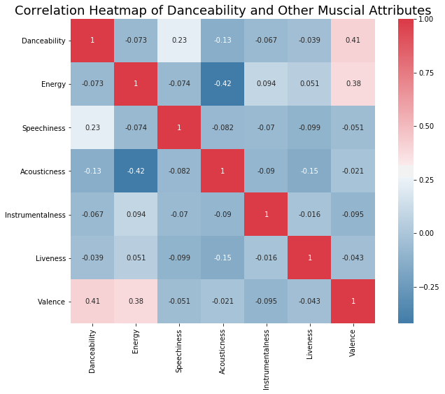

```python
plt.figure(figsize=(12,8))
plt.title("Correlation Heatmap of Danceability and Other Muscial Attributes", fontsize=18)
sns.heatmap(heats,cmap=sns.diverging_palette(240, 10, as_cmap=True), square=True, annot=True)
plt.show()
```

# Hypothesis Testing and Linear Regression

Our group will be perfoming linear regression to model a danceability target predicition based on the other audio features. Linear regression is a machine learning algorithm based on supervised learning.

We will inspect 10 musical attributes of a song and determine their correlation to the song's danceability

**Null Hypothesis:** No attribute is significantly correlated to danceability

**Alternative Hypothesis:** At least one atribute is significantly correlated to danceability

We will use statsmodel's ordinary least squares model to fit a multiple linear regression model, where the dependent variable is danceability, and the independent variables are energy, key, loudness, mode, speechiness, acousticness, instrumentalness, liveness, valence, and tempo. We can measure how close the data is to the fitted regresion line by calculating the R-squared score. It can range from 0 to 1, with 0 being not accurate at all and 1 being 100% accurate.

```python
ivs = ['Energy', 'Key', 'Loudness', 'Mode', 'Speechiness', 'Acousticness', 'Instrumentalness', 'Liveness', 'Valence', 'Tempo']
x = data[ivs]
y = data['Danceability']

# fit data
ols_model = api.OLS(y,x).fit()
ols_model.summary()
```

OLS Regression Results

| Dep. Variable: | Danceability | R-squared: | 0.969 |
| --- | --- | --- | --- |
| Model: | OLS | Adj. R-squared: | 0.966 |
| Method: | Least Squares | F-statistic: | 284.6 |
| Date: | Mon, 16 Dec 2019 | Prob (F-statistic): | 1.46e-63 |
| Time: | 11:34:41 | Log-Likelihood: | 64.074 |
| No. Observations: | 100 | AIC: | -108.1 |
| Df Residuals: | 90 | BIC: | -82.10 |
| Df Model: | 10 |  |  |
| Covariance Type: | nonrobust |  |  |

|  | coef | std err | t | P>\|t\| | [0.025 | 0.975] |
| --- | --- | --- | --- | --- | --- | --- |
| Energy | 0.2639 | 0.093 | 2.844 | 0.006 | 0.080 | 0.448 |
| Key | 0.0018 | 0.004 | 0.487 | 0.628 | -0.006 | 0.009 |
| Loudness | -0.0424 | 0.008 | -5.250 | 0.000 | -0.058 | -0.026 |
| Mode | 0.0395 | 0.028 | 1.392 | 0.167 | -0.017 | 0.096 |
| Speechiness | 0.2578 | 0.141 | 1.834 | 0.070 | -0.021 | 0.537 |
| Acousticness | -0.0500 | 0.067 | -0.742 | 0.460 | -0.184 | 0.084 |
| Instrumentalness | -0.0645 | 1.044 | -0.062 | 0.951 | -2.138 | 2.009 |
| Liveness | 0.0649 | 0.124 | 0.522 | 0.603 | -0.182 | 0.312 |
| Valence | 0.4408 | 0.074 | 5.994 | 0.000 | 0.295 | 0.587 |
| Tempo | 0.0002 | 0.000 | 0.337 | 0.737 | -0.001 | 0.001 |

| Omnibus: | 4.341 | Durbin-Watson: | 1.946 |
| --- | --- | --- | --- |
| Prob(Omnibus): | 0.114 | Jarque-Bera (JB): | 3.665 |
| Skew: | -0.398 | Prob(JB): | 0.160 |
| Kurtosis: | 3.495 | Cond. No. | 9.59e+03 |

Warnings:  
[1] Standard Errors assume that the covariance matrix of the errors is correctly specified.  
[2] The condition number is large, 9.59e+03. This might indicate that there are  
strong multicollinearity or other numerical problems.

The column "P>|t|" indicates the p-value of each atribute. A p-value less than 0.05 (the benchmark in science) indicates statistical significance. According our results, energy, loudness, and valence all have p-values less than 0.05. As a result, it is false to say that no variation exists between the variables.

**Conclusion:** We reject the null hypothesis and conclude that danceability is correlated to energy, loudness, and valence.

## Predicting Danceability Based on other Attributes

We will create a multiple linear regression model with scikit-learn in order to predict the danceability of a song based on the ten previously inspected song attributes. We can find its accuracy with an R-squared measurement.

```python
lr = linear_model.LinearRegression().fit(x,y)
print("R-squared score: " + str(lr.score(x,y)))
```

```
R-squared score: 0.3796686733488578
```

This score indicates that the model's predictions are only about 38% accurate to the actual danceability scores, which is not quite ideal.

We will now plot one of our model's results against actual values, showing their relationship to gain further insight.

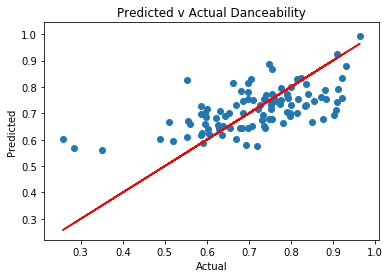

```python
y_hats = lr.predict(x)
plt.scatter(y, y_hats)
plt.plot(y, y, color="red")
plt.xlabel("Actual")
plt.ylabel("Predicted")
plt.title("Predicted v Actual Danceability")
plt.show()
```

This certainly is not a tight fit, but there does exist a positive correlation between actual and predicted danceability. We can see that the majority of points fall in the 0.6 - 0.9 range.

## Conclusion and Further Exploration

[figure not shown]

*Popular rapper and cultural icon Bobby Shmurda dancing with his crew, GS9*  
*Picture from* [slate.com](http://www.slate.com/blogs/browbeat/2014/07/15/shmoney_dance_bobby_shmurda_viral_hit_goes_from_vines_to_beyonce_and_jay.html)

The most popular songs of 2018 all had measureable danceability. The most popular of these, however, were not the most danceable. Some artists, though, tended to be more danceable than others. Dividing into the data may have the answers as to why.

We were able to find that danceability was statistically significantly correlated to the song attributes energy, loudness, and valence. These all logically make sense, as it would make sense for one to dance to a more positive and lively song. However, the predictive model we constructed using linear regression could not obtain great results, as it obtained an R-squared score around 0.38.

Danceability, after all, is a subjective measurement, as one may judge how encouraging a song is differently from another person. Apple Music may have a different way of measuring danceability from Spotify, for example. Also, Spotify may also have other song attributes that it measures that it does not release to the public.

Songs are also not uniform, as throughout a given song, the beat changes, the singers change, their style may change, etc. However, the statistics from spotify describe songs as if they are uniform. This would impact danceability. For example, a song may be quite calm for the most part, but then have a beat drop, which is very danceable for many people. Therefore, the given statistics may not be accurate indicators of danceability.

Moving forward with this tutorial, we recommend doing this with similar datasets from other years to see if the change in danceability varies from year to year. Also, the time interval can be changed to see how danceability differs according to time period, for example by decade. Further exploration can be futher divided into categories like danceability by genre, artist, or album.

We hope you enjoyed this tutorial as much as we did. This topic was very interesting for us do research and analyze, and I hope it was for you as well. Now, the next time you dance to a song, we hope you think about all the audio elements to that song that make you wanna bust down.